# Particle MCMC and model comparison

**Estimated time**: 75 minutes

Slides

# Introduction

In the previous session, we learned how particle filters estimate likelihoods for stochastic models by simulating many trajectories and weighting them by how well they match observations. We also calibrated the number of particles needed for reliable inference.

Now we’ll put this into practice. This session shows how to combine particle filters with Metropolis-Hastings to perform full Bayesian inference on stochastic models — the Particle Marginal Metropolis-Hastings (PMMH) algorithm.

Fitting the stochastic model also puts us in a position to compare models for the first time. Two comparisons run through the second half of the session: the stochastic fit against the deterministic one, and SEITL against SEIT4L, which differ in how they distribute the duration of temporary immunity.

**NoteComing from R?**

In R, particle MCMC is available through [`pomp`](https://kingaa.github.io/pomp/) (the `pmcmc()` function) and the [`mcstate`](https://mrc-ide.github.io/mcstate/) package (part of the odin/dust/mcstate ecosystem). The concepts are identical; only the implementation differs.

# Objectives

In this session you will:

1. Implement PMMH using our calibrated particle filter from the previous session
2. Fit the stochastic SEIT4L model to the Tristan da Cunha outbreak
3. Compare stochastic vs deterministic model fits
4. Understand why PMMH requires long chains and adaptive proposals
5. Compare two competing models with DIC and with posterior predictive checks

**ImportantReminder: Stochastic variability**

PMMH uses particle filters internally, introducing two sources of randomness: the MCMC proposals and the particle filter likelihood estimates. Your chains will look different from others’ runs. Focus on whether the chains have converged (diagnostics), not exact values.

**WarningComputational requirements**

PMMH combines particle filters with MCMC, making it computationally demanding. For this session:

- **Memory**: ~4 GB RAM recommended
- **Runtime**: Each MCMC iteration takes 0.1-0.5 seconds (256 particles)
- **Full inference**: 10,000 iterations takes ~30-60 minutes; we use pre-computed chains for the main analysis
- **Short test runs**: the demonstration below runs 500 warmup iterations and 500 kept ones, so budget roughly twice what 500 iterations alone would cost

The pre-computed chains (loaded from `data/`) were generated with 500,000 iterations over several hours.

# Setup

## Source file

The source file of this session is located at `sessions/pmcmc.qmd`.

## Load libraries

```julia
using Random ## for random numbers
using Distributions ## for probability distributions
using DifferentialEquations ## for differential equations
using DataFrames ## for data frames
using Plots ## for plots
using StatsPlots ## for statistical plots
using Turing ## for probabilistic programming and MCMC
using MCMCChains ## to rebuild a chain object from the saved CSVs
using AdvancedMH ## for custom MH proposals
using CSV ## for CSV file reading
using StatsBase ## for statistical functions
using JLD2 ## for loading pre-computed chains
using SSMProblems ## for state-space model interface
using GeneralisedFilters ## for particle filtering
using ForwardDiff ## for stripping Dual numbers in non-differentiable likelihoods
using DrWatson
```

## Load the course package

This loads the `MFIIDD` course package, which provides the helper functions used throughout — including the same particle filter implementation from the previous session.

```julia
using MFIIDD
```

**NoteSEIT4L Particle Filter Implementation**

Gillespie step ([`src/seit4l_gillespie.jl`](https://github.com/mfiidd/mfiidd/blob/main/src/seit4l_gillespie.jl)):

```julia
using Random

"""
    gillespie_step(rng, state, θ, dt=1.0)

Simulate SEIT4L for `dt` time units using the Gillespie algorithm.

# Arguments
- `rng`: Random number generator
- `state`: Vector [S, E, I, T1, T2, T3, T4, L]
- `θ`: Parameter dictionary with keys :R_0, :D_lat, :D_inf, :α, :D_imm
- `dt`: Length of the simulation interval (default 1.0, i.e. one day)

# Returns
- `(new_state, incidence)`: Updated state and number of new cases over `dt`
"""
function gillespie_step(
    rng::AbstractRNG,
    state::Vector{Float64},
    θ::Dict,
    dt::Float64 = 1.0,
)
    β = θ[:R_0] / θ[:D_inf]
    ϵ = 1.0 / θ[:D_lat]
    ν = 1.0 / θ[:D_inf]
    τ = 4.0 / θ[:D_imm]
    α = θ[:α]

    # Copy state for modification
    s = copy(state)

    # Stoichiometry: how each transition changes [S, E, I, T1, T2, T3, T4, L]
    stoich = [
        [-1, 1, 0, 0, 0, 0, 0, 0],   # S → E (infection)
        [0, -1, 1, 0, 0, 0, 0, 0],   # E → I (becoming infectious)
        [0, 0, -1, 1, 0, 0, 0, 0],   # I → T1 (recovery)
        [0, 0, 0, -1, 1, 0, 0, 0],   # T1 → T2
        [0, 0, 0, 0, -1, 1, 0, 0],   # T2 → T3
        [0, 0, 0, 0, 0, -1, 1, 0],   # T3 → T4
        [1, 0, 0, 0, 0, 0, -1, 0],   # T4 → S (immunity wanes)
        [0, 0, 0, 0, 0, 0, -1, 1],    # T4 → L (long-term immunity)
    ]

    function rates(s)
        S, E, I, T1, T2, T3, T4, L = s
        N = S + E + I + T1 + T2 + T3 + T4 + L
        [β*S*I/N, ϵ*E, ν*I, τ*T1, τ*T2, τ*T3, (1-α)*τ*T4, α*τ*T4]
    end

    # Simulate up to `dt` time units
    t, daily_inc = 0.0, 0
    while t < dt
        r = rates(s)
        total_rate = sum(r)
        total_rate ≤ 0 && break

        # Time to next event
        τ_wait = randexp(rng) / total_rate
        t + τ_wait > dt && break
        t += τ_wait

        # Select which event occurs
        cum, rnd, event = 0.0, rand(rng) * total_rate, 0
        for i in 1:8
            cum += r[i]
            if rnd ≤ cum
                event = i
                break
            end
        end

        # Apply the transition
        for j in 1:8
            s[j] += stoich[event][j]
        end

        # E → I transitions count as new cases
        event == 2 && (daily_inc += 1)
    end

    return s, daily_inc
end

"""
    gillespie_step_seit4l!(state, θ, dt)

In-place version for simple bootstrap filter (no RNG argument, uses global RNG).
"""
function gillespie_step_seit4l!(state::Vector{Float64}, θ::Dict, dt::Float64 = 1.0)
    new_state, inc = gillespie_step(Random.default_rng(), state, θ, dt)
    for i in 1:8
        state[i] = new_state[i]
    end
    return inc
end
```

SSMProblems interface ([`src/seit4l_ssm_interface.jl`](https://github.com/mfiidd/mfiidd/blob/main/src/seit4l_ssm_interface.jl)):

```julia
using Random
using Distributions
using SSMProblems

"""
SEIT4L latent dynamics.
State vector: [S, E, I, T1, T2, T3, T4, L, daily_inc]
The last element tracks daily incidence for the observation process.
"""
struct SEIT4LDynamics <: SSMProblems.LatentDynamics
    θ::Dict{Symbol, Float64}
end

function SSMProblems.simulate(
    rng::AbstractRNG,
    dyn::SEIT4LDynamics,
    step::Integer,
    prev_state;
    kwargs...,
)
    state = collect(prev_state[1:8])  # Extract compartments
    new_state, daily_inc = gillespie_step(rng, state, dyn.θ)
    return vcat(new_state, daily_inc)  # Append daily incidence
end

"""
Poisson observation process.
Observes daily incidence (last element of state) with reporting rate ρ.
"""
struct PoissonObservation <: SSMProblems.ObservationProcess
    ρ::Float64
end

function SSMProblems.distribution(obs::PoissonObservation, step::Integer, state; kwargs...)
    daily_inc = state[end]
    Poisson(max(obs.ρ * daily_inc, 1e-10))
end

"""
Initial state distribution (deterministic).
"""
struct SEIT4LInitial <: SSMProblems.StatePrior
    init_state::Vector{Float64}
end

function SSMProblems.simulate(rng::AbstractRNG, prior::SEIT4LInitial; kwargs...)
    vcat(prior.init_state, 0.0)  # Append 0 for initial daily incidence
end
```

Bootstrap filter runner ([`src/seit4l_runner.jl`](https://github.com/mfiidd/mfiidd/blob/main/src/seit4l_runner.jl)):

```julia
using Random: default_rng
using GeneralisedFilters: GeneralisedFilters, BF, DenseAncestorCallback, get_ancestry
using ForwardDiff: value
using SSMProblems: StateSpaceModel

"""
    run_particle_filter(θ, obs, n_particles; init_state)

Run bootstrap particle filter for SEIT4L and return log-likelihood.

# Arguments
- `θ`: Parameter dictionary (must include :R_0, :D_lat, :D_inf, :α, :D_imm, :ρ)
- `obs`: Vector of observed daily incidence
- `n_particles`: Number of particles
- `init_state`: Initial state vector [S, E, I, T1, T2, T3, T4, L]

# Returns
- `log_likelihood`: Estimated log-likelihood
"""
function run_particle_filter(
    θ,
    obs,
    n_particles;
    init_state = [279.0, 0.0, 2.0, 3.0, 0.0, 0.0, 0.0, 0.0],
)
    # Coerce init_state to Float64 so callers can pass an integer vector
    # (e.g. [279, 0, 2, ...]) without hitting SEIT4LInitial's Vector{Float64}
    # signature.
    init_state_f64 = collect(Float64.(init_state))
    length(init_state_f64) == 8 ||
        throw(ArgumentError("init_state must be [S, E, I, T1, T2, T3, T4, L]"))

    # Strip ForwardDiff Duals before constructing the SSM components: the
    # bootstrap filter is non-differentiable, and SEIT4LDynamics /
    # PoissonObservation declare concrete Float64 fields. Mirrors the pattern
    # used in sessions/pmcmc.qmd.
    θ_f64 = Dict{Symbol, Float64}(k => value(v) for (k, v) in θ)

    # Define SSM components
    initial = SEIT4LInitial(init_state_f64)
    dynamics = SEIT4LDynamics(θ_f64)
    observation = PoissonObservation(θ_f64[:ρ])

    # Create state-space model
    model = StateSpaceModel(initial, dynamics, observation)

    # Run bootstrap particle filter
    rng = default_rng()
    algo = BF(n_particles)  # Bootstrap Filter
    _, log_lik = GeneralisedFilters.filter(rng, model, algo, obs)

    return log_lik
end

"""
    filtered_incidence(θ, obs, n_particles; init_state)

Run the SEIT4L bootstrap filter and return one draw from the smoothing
distribution of daily incidence, that is a latent path conditioned on `obs`.

`DenseAncestorCallback` records the particles and their ancestor indices at
every step, so a particle drawn from the final weights can be traced back to
give its whole path. The last element of the SEIT4L state is the daily
incidence, so reading that element off the path gives the trajectory directly.

# Returns
- `Vector{Float64}` of length `length(obs)`, the filtered daily incidence
"""
function filtered_incidence(
    θ,
    obs,
    n_particles;
    init_state = [279.0, 0.0, 2.0, 3.0, 0.0, 0.0, 0.0, 0.0],
)
    θ_f64 = Dict{Symbol, Float64}(k => value(v) for (k, v) in θ)
    model = StateSpaceModel(
        SEIT4LInitial(collect(Float64.(init_state))),
        SEIT4LDynamics(θ_f64),
        PoissonObservation(θ_f64[:ρ]),
    )

    callback = DenseAncestorCallback(nothing)
    final, _ =
        GeneralisedFilters.filter(default_rng(), model, BF(n_particles), obs; callback)

    ## draw one particle in proportion to its final weight, then follow its
    ## ancestry back to the start
    log_w = getfield.(final.particles, :log_w)
    w = exp.(log_w .- maximum(log_w))
    u = rand() * sum(w)
    idx = findfirst(>=(u), cumsum(w))
    path = get_ancestry(callback.container, idx)

    return [path[t][end] for t in 1:length(obs)]
end
```

## Initialisation

We set a random seed for reproducibility.

```julia
Random.seed!(1234)
```

```
TaskLocalRNG()
```

# Recap: Data and particle filter

We load the Tristan da Cunha data and set up initial conditions:

```julia
# Load Tristan da Cunha data
flu_tdc = CSV.read(datadir("flu_tdc_1971.csv"), DataFrame)

# Initial state for SEIT4L
init_state = Dict(
    :S => 279.0,
    :E => 0.0,
    :I => 2.0,
    :T1 => 3.0,
    :T2 => 0.0,
    :T3 => 0.0,
    :T4 => 0.0,
    :L => 0.0
)
```

```
Dict{Symbol, Float64} with 8 entries:
  :I  => 2.0
  :T2 => 0.0
  :L  => 0.0
  :S  => 279.0
  :T4 => 0.0
  :T1 => 3.0
  :E  => 0.0
  :T3 => 0.0
```

In the Particle Filters session, we:

1. Implemented the SEIT4L Gillespie simulator (`gillespie_step`)
2. Defined the [SSMProblems.jl](https://turinglang.org/SSMProblems.jl/SSMProblems/dev/) interface (`SEIT4LDynamics`, `PoissonObservation`, `SEIT4LInitial`)
3. Calibrated the particle count against the SD of the log-likelihood estimate, which put the minimum acceptable count at 64

All these components were loaded via `using MFIIDD` in the setup above (defined in [`src/seit4l_gillespie.jl`](https://github.com/mfiidd/mfiidd/blob/main/src/seit4l_gillespie.jl), [`src/seit4l_ssm_interface.jl`](https://github.com/mfiidd/mfiidd/blob/main/src/seit4l_ssm_interface.jl), and [`src/seit4l_runner.jl`](https://github.com/mfiidd/mfiidd/blob/main/src/seit4l_runner.jl)). Now we’ll use them for full Bayesian inference.

In your own work, you should run prior and posterior predictive checks when fitting models. We skip them for now to focus on the PMMH algorithm.

# Particle MCMC (PMMH) with Turing.jl

Now that we have a calibrated particle filter, we can use it for inference. We’ll implement **Particle Marginal Metropolis-Hastings (PMMH)** - one of the two main particle MCMC algorithms from [Andrieu et al. (2010)](https://doi.org/10.1111/j.1467-9868.2009.00736.x).

PMMH uses the particle filter to estimate the likelihood, then does standard Metropolis-Hastings on the parameters. In Turing.jl, we implement this by:

1. Defining priors as usual with `~`
2. Building a state-space model and running `GeneralisedFilters.filter()` to get the log-likelihood
3. Adding it to the model’s log-probability with `@addlogprob!`
4. Sampling with `MH()` with custom random-walk proposals

```julia
"""
PMMH model for SEIT4L inference.
Uses GeneralisedFilters for likelihood estimation.
"""
@model function pmmh_seit4l(obs, n_particles)
    # Weakly informative priors
    R_0 ~ truncated(Normal(3.0, 2.0), lower=1.0)
    D_lat ~ truncated(Normal(2.0, 1.0), lower=0.5)
    D_inf ~ truncated(Normal(3.0, 2.0), lower=0.5)
    α ~ Beta(2, 2)
    D_imm ~ truncated(Normal(15.0, 10.0), lower=1.0)
    ρ ~ Beta(2, 2)

    # Create parameter dictionary; extract underlying values so ForwardDiff
    # Duals (used only by Turing's gradient-based init probe) don't flow into
    # the particle filter, which is non-differentiable anyway.
    θ = Dict(:R_0 => ForwardDiff.value(R_0),
             :D_lat => ForwardDiff.value(D_lat),
             :D_inf => ForwardDiff.value(D_inf),
             :α => ForwardDiff.value(α),
             :D_imm => ForwardDiff.value(D_imm),
             :ρ => ForwardDiff.value(ρ))

    # Build state-space model
    # The SSMProblems interface expects a plain vector, not a Dict
    # Order: [S, E, I, T1, T2, T3, T4, L]
    init_state = [279.0, 0.0, 2.0, 3.0, 0.0, 0.0, 0.0, 0.0]
    ssm = StateSpaceModel(SEIT4LInitial(init_state),
                          SEIT4LDynamics(θ),
                          PoissonObservation(θ[:ρ]))

    # Run particle filter to estimate log-likelihood
    _, log_lik = GeneralisedFilters.filter(Random.default_rng(), ssm, BF(n_particles), obs)

    # Add log-likelihood to model (priors are already included via ~)
    Turing.@addlogprob! log_lik
end
```

```
Main.Notebook.pmmh_seit4l
```

**TipCode explainer**

- **`StateSpaceModel(...)`** - assembles the state-space model from initial distribution, dynamics, and observation components defined in [`src/seit4l_ssm_interface.jl`](https://github.com/mfiidd/mfiidd/blob/main/src/seit4l_ssm_interface.jl).
- **`GeneralisedFilters.filter(...)`** - runs the bootstrap particle filter (`BF`) and returns the estimated log-likelihood. `Random.default_rng()` provides the global random number generator — this is Julia’s way of passing randomness explicitly rather than relying on a hidden global state.
- [`@addlogprob!`](https://turinglang.org/DynamicPPL.jl/stable/api/#DynamicPPL.@addlogprob!) - manually adds the particle filter’s log-likelihood estimate to the model. The priors specified with `~` still contribute automatically. This is the [recommended pattern](https://github.com/TuringLang/Turing.jl/issues/2428) for integrating external likelihood estimators with Turing.
- **Why 256 particles?** PMMH acceptance depends on the variance of the log-likelihood estimate. Using more particles reduces variance but increases computation. The calibration in the previous session put the minimum at 64, measured at a single parameter set; how noisy the estimate is depends on where in the posterior you are, so it is safer to go somewhat higher, and worth checking the count again once you have a posterior to check it against.

Now let’s run PMMH. Unlike standard MCMC where NUTS auto-tunes proposals, PMMH requires Metropolis-Hastings because the particle filter likelihood is not differentiable.

Let’s start with a short chain to see the challenges:

```julia
# Define model with 256 particles
model_pmmh = pmmh_seit4l(flu_tdc.obs, 256)

# Run a short chain with RAM
# externalsampler() wraps an AdvancedMH.jl sampler for use with Turing models
# num_warmup=500 gives it 500 discarded iterations to adapt in
# check_model=false is needed because our model uses @addlogprob! instead of standard ~ syntax
chain_short = sample(
    model_pmmh,
    externalsampler(AdvancedMH.RobustAdaptiveMetropolis()),
    500;
    num_warmup=500,
    check_model=false,
    progress=false
)
```

```
╭─FlexiChain (500 iterations, 1 chain) ────────────────────────────────────────╮
│ ↓ iter  = 501:1000                                                           │
│ → chain = 1:1                                                                │
│                                                                              │
│ Parameters (6) ── AbstractPPL.VarName                                        │
│  Float64  R_0, D_lat, D_inf, α, D_imm, ρ                                     │
│                                                                              │
│ Extras (6)                                                                   │
│  Float64  logα, η, logprior, loglikelihood, logjoint                         │
│  Bool     accepted                                                           │
╰──────────────────────────────────────────────────────────────────────────────╯
```

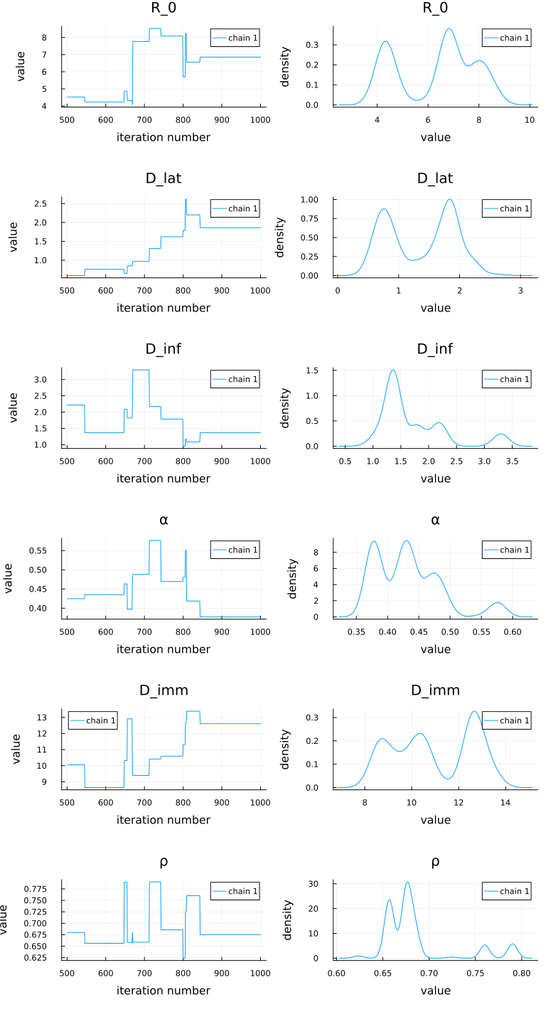

```julia
# Plot the short chain
plot(chain_short)
```

**WarningNotice the poor mixing**

Look carefully at the trace plots above. You should see:

- **Flat stretches (plateaus)**: The chain gets stuck at the same value for many iterations
- **Slow wandering**: Instead of rapidly exploring, the chain drifts gradually

With only 500 samples, the chain hasn’t had time to properly explore the posterior.

Two details of the figure are worth reading. The iteration axis starts at 500 because the 500 warmup iterations are discarded, so what you are looking at is the chain *after* RAM has had a go at adapting. And it is still stuck: adaptation needs far more than 500 iterations to find a proposal that suits this posterior, so those flat stretches are not simply a badly chosen step size that a little tuning would cure.

**TipExercise: Run your own short PMMH chain**

Try running a short PMMH chain yourself:

1. Run `sample(model_pmmh, externalsampler(AdvancedMH.RobustAdaptiveMetropolis()), 200; num_warmup=200, check_model=false)` and look at the trace plots
2. What acceptance rate does the sampler achieve? (Look at the proportion of samples that change between iterations)
3. Try reducing the particle count to 64: `pmmh_seit4l(flu_tdc.obs, 64)`. How does this affect mixing? Is it faster but noisier?
4. Compare to the pre-computed chain loaded below — how many more iterations were needed for convergence?

**TipWhat to look for**

Expect a low acceptance rate and a trace plot with long flat stretches — the chain sitting at one parameter value for many iterations before moving. That is the signature of a noisy likelihood: once the sampler lands on a point whose likelihood was over-estimated by chance, every honest proposal has to beat an inflated number, so it stays put.

**Against the pre-computed chain**, 200 iterations is nowhere near enough. The saved chain runs orders of magnitude longer, and comparing your trace with it makes the point better than any convergence statistic: a short PMMH chain does not look obviously broken, it just has not gone anywhere yet.

## Why is PMMH mixing difficult?

The particle filter gives a *noisy estimate* of the likelihood. Even at the same parameters, different runs give different values. This noise means proposals that would be accepted with an exact likelihood may be rejected (and vice versa), slowing exploration.

*Robust Adaptive Metropolis (RAM)* helps by learning the posterior covariance structure during its warmup iterations ([Vihola, 2012](https://doi.org/10.1007/s11222-011-9269-5)), and then sampling with the proposal it has learned.

**NotePre-computed chains**

Running PMMH with RAM for good mixing takes several hours. We load pre-computed chains here: 50,000 warmup iterations for RAM to adapt in, then 450,000 kept and thinned by 50. See `scripts/generate_pmcmc_seit4l.jl` if you want to run it yourself.

```julia
# Load pre-computed SEIT4L chain with good mixing
chain_df = CSV.read(datadir("pmcmc_seit4l_chain.csv"), DataFrame)
chain_pmcmc = Chains(Matrix(chain_df[:, [:R_0, :D_lat, :D_inf, :α, :D_imm, :ρ]]),
                     [:R_0, :D_lat, :D_inf, :α, :D_imm, :ρ])
```

```
Chains MCMC chain (9000×6×1 Array{Float64, 3}):

Iterations        = 1:1:9000
Number of chains  = 1
Samples per chain = 9000
parameters        = R_0, D_lat, D_inf, α, D_imm, ρ

Use `describe(chains)` for summary statistics and quantiles.
```

```julia
# Display chain summary
display(chain_pmcmc)
```

```
Chains MCMC chain (9000×6×1 Array{Float64, 3}):

Iterations        = 1:1:9000
Number of chains  = 1
Samples per chain = 9000
parameters        = R_0, D_lat, D_inf, α, D_imm, ρ

Use `describe(chains)` for summary statistics and quantiles.
```

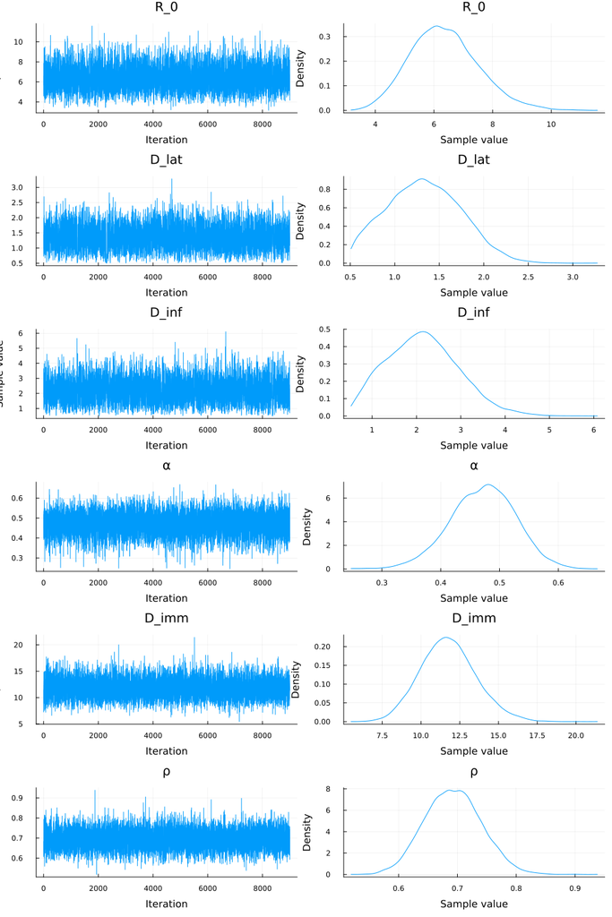

```julia
# Plot trace plots - much better mixing!
plot(chain_pmcmc)
```

The saved chain also records whether each draw was accepted, which is the diagnostic that says whether RAM’s adaptation worked:

```julia
# `accepted` is kept alongside the parameters, so we can check the rate RAM reached
println("acceptance rate: ", round(100 * mean(chain_df.accepted), digits = 1), "%")
```

```
acceptance rate: 23.6%
```

That is the target RAM aims for, and it is the payoff from the warmup iterations described below.

**TipThe case for Robust Adaptive Metropolis**

With standard MH and independent proposals, mixing is poor when parameters are correlated. The sampler proposes moves that go “against” the correlation structure and gets rejected.

**RAM solves this** by learning the posterior covariance ([Vihola, 2012](https://doi.org/10.1007/s11222-011-9269-5)). During warmup it:

1. Adapts the proposal covariance to match the posterior shape
2. Scales proposals towards ~23% acceptance (optimal for random-walk MH)

The adaptation happens in the warmup iterations only, with a step size that decays as $n^{-0.6}$; at the end of warmup the proposal is fixed and the chain that follows is an ordinary Metropolis chain. This is similar to how NUTS adapts its mass matrix during warmup, but works for non-differentiable likelihoods like particle filters.

**WarningWarmup is the whole adaptation budget**

Because RAM only adapts during warmup, `num_warmup` is not a formality: with no warmup the proposal stays at the identity matrix it started from and acceptance sits near 0.5% instead of the 23% RAM aims for, whatever the chain length. The saved chains use 50,000 warmup iterations.

# Comparing with deterministic model fits

We quickly fit the deterministic SEIT4L model for comparison:

```julia
"""
SEIT4L deterministic model.
"""
function seit4l_ode!(du, u, p, t)
    R_0, D_lat, D_inf, α, D_imm = p
    β = R_0 / D_inf
    ϵ = 1.0 / D_lat
    ν = 1.0 / D_inf
    τ = 4.0 / D_imm

    S, E, I, T1, T2, T3, T4, L, Inc = u
    N = S + E + I + T1 + T2 + T3 + T4 + L

    du[1] = -β * S * I / N + (1 - α) * τ * T4
    du[2] = β * S * I / N - ϵ * E
    du[3] = ϵ * E - ν * I
    du[4] = ν * I - τ * T1
    du[5] = τ * T1 - τ * T2
    du[6] = τ * T2 - τ * T3
    du[7] = τ * T3 - τ * T4
    du[8] = α * τ * T4
    du[9] = ϵ * E
end

@model function seit4l_deterministic_model(init_state, times, n_obs)
    # Weakly informative priors
    R_0 ~ truncated(Normal(3.0, 2.0), lower=1.0)
    D_lat ~ truncated(Normal(2.0, 1.0), lower=0.5)
    D_inf ~ truncated(Normal(3.0, 2.0), lower=0.5)
    α ~ Beta(2, 2)
    D_imm ~ truncated(Normal(15.0, 10.0), lower=1.0)
    ρ ~ Beta(2, 2)

    # Solve ODE; promote u0 to the parameter element type so ForwardDiff Duals
    # propagate through the solution
    params = [R_0, D_lat, D_inf, α, D_imm]
    T = eltype(params)
    u0 = T[init_state[:S], init_state[:E], init_state[:I],
           init_state[:T1], init_state[:T2], init_state[:T3], init_state[:T4],
           init_state[:L], 0.0]

    prob = ODEProblem(seit4l_ode!, u0, (times[1], times[end]), params)
    sol = solve(prob, Tsit5(), saveat=times)

    # Reject parameter draws that drive the solver to fail early; the gradient
    # probe in NUTS init occasionally lands on combinations where the ODE only
    # saves the initial timepoint.
    if !SciMLBase.successful_retcode(sol) || length(sol.t) != length(times)
        Turing.@addlogprob! -Inf
        return
    end

    # Extract daily incidence. There is one fewer difference than there are time
    # points, and `inc_daily[i]` is the incidence over the day ending at
    # `times[i + 1]`, which is the day the i-th observation counts. Prepending a
    # zero instead would match every observation to the previous day.
    inc_cumulative = sol[9, :]
    inc_daily = diff(inc_cumulative)

    # Likelihood: Poisson observations
    lambdas = [max(ρ * inc_daily[i], 1e-10) for i in 1:n_obs]
    obs ~ arraydist(Poisson.(lambdas))
end
```

```
seit4l_deterministic_model (generic function with 2 methods)
```

**TipWhy `|` conditioning here but `@addlogprob!` above?**

The deterministic model uses `obs ~ arraydist(Poisson.(lambdas))` — the likelihood is expressed as a `~` statement, so Turing can condition on the data directly with `|`.

The stochastic `pmmh_seit4l` model uses an *external* likelihood estimator (the particle filter via `GeneralisedFilters.filter`), which returns a log-likelihood that we add manually with `@addlogprob!`. In that model, there is no `obs ~` statement in the model body — `obs` enters as a function argument passed to the filter — so `|` has nothing to condition on.

In short: use `|` when the likelihood is a `~` statement; use `@addlogprob!` when the likelihood comes from an external computation.

```julia
# Fit deterministic model
times_obs = 0.0:1.0:59.0
model_det = seit4l_deterministic_model(init_state, times_obs, length(flu_tdc.obs)) | (; obs = flu_tdc.obs)
chain_det = sample(model_det, NUTS(), 2000, progress=false)
```

[output not shown]

```
╭─FlexiChain (2000 iterations, 1 chain) ───────────────────────────────────────╮
│ ↓ iter  = 1001:3000                                                          │
│ → chain = 1:1                                                                │
│                                                                              │
│ Parameters (6) ── AbstractPPL.VarName                                        │
│  Float64  R_0, D_lat, D_inf, α, D_imm, ρ                                     │
│                                                                              │
│ Extras (14)                                                                  │
│  Int64    n_steps, tree_depth                                                │
│  Bool     is_accept, numerical_error                                         │
│  Float64  acceptance_rate, log_density, hamiltonian_energy,                  │
│           hamiltonian_energy_error, max_hamiltonian_energy_error, step_size, │
│           nom_step_size, logprior, loglikelihood, logjoint                   │
╰──────────────────────────────────────────────────────────────────────────────╯
```

**Plotting code**

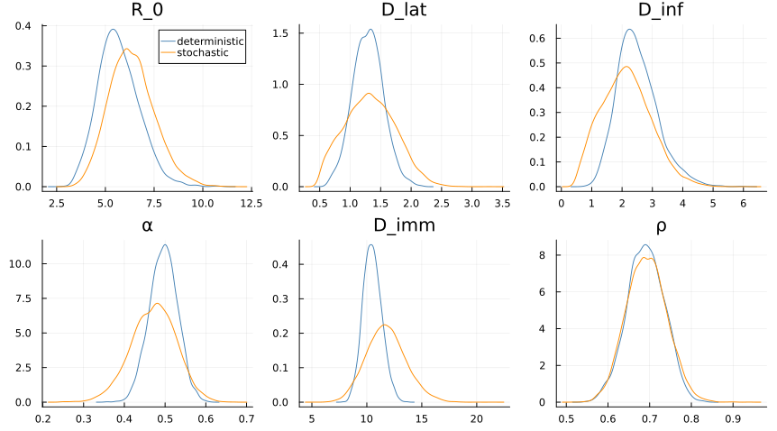

```julia
## Compare posteriors, both models overlaid on one panel per parameter
params = [:R_0, :D_lat, :D_inf, :α, :D_imm, :ρ]
panels = map(enumerate(params)) do (i, par)
    ## pull the draws out as plain vectors so the series labels are ours
    pl = density(vec(chain_det[par]), title = string(par), label = "deterministic",
                 colour = :steelblue, legend = i == 1 ? :topright : false)
    density!(pl, vec(chain_pmcmc[par]), label = "stochastic", colour = :darkorange)
end

plot(panels..., layout = (2, 3), size = (900, 500))
```

**TipExercise: Interpret the stochastic vs deterministic comparison**

Look at the posterior density plots above and compare the two models:

1. Which model gives wider posterior distributions? Why would accounting for stochastic variability change the uncertainty in parameter estimates?
2. Focus on the $\alpha$ parameter (probability of long-term immunity). Do the two models agree on its value?
3. For a population of 284 people, do you think the deterministic approximation is reasonable, or does stochasticity matter?

**TipWhat to look for**

**The stochastic model gives wider posteriors, but by very different amounts across the six parameters.** The clearest case is $D_\mathrm{imm}$, whose posterior standard deviation roughly doubles, followed by $\alpha$ and $D_\mathrm{lat}$, which grow by about three fifths. $R_0$ grows by about a tenth, and the reporting rate $\rho$ barely moves at all, which makes sense: it is pinned by the total number of cases either way.

The direction is the same everywhere, and it should be. The deterministic model attributes every discrepancy between prediction and data to observation noise, so the parameters have to explain everything and get pinned down tightly. The stochastic model has a second source of variation available — the epidemic itself could have gone differently — so a wider range of parameters remains consistent with what was seen. A narrower posterior is not a better one when the narrowness comes from a mechanism you left out.

**On $\alpha$**, look at whether the intervals overlap rather than whether the means match. Disagreement here matters more than for the other parameters, because $\alpha$ controls how much of the population returns to susceptible and therefore whether a second wave happens at all.

**On 284 people**: stochasticity matters. Demographic noise scales roughly as $1/\sqrt{N}$, so a few hundred people is squarely in the regime where chance events change the trajectory — and Tristan da Cunha is the standard example precisely because the population is small enough for it to show. The deterministic approximation earns its keep in populations of hundreds of thousands, not hundreds.

For the Tristan da Cunha outbreak with only 284 individuals, demographic stochasticity plays a significant role. The stochastic model typically shows wider posteriors because it accounts for an additional source of variability — the randomness of individual infection events — that the deterministic model ignores. The deterministic model is much faster to fit and useful for initial exploration, but for small populations the stochastic model gives more honest uncertainty estimates.

# Model comparison: SEITL vs SEIT4L

In the SEITL session, we introduced two model variants that both explain the two-wave pattern through temporary immunity:

- **SEITL**: Single T compartment with exponential duration (memoryless)
- **SEIT4L**: Four T sub-compartments giving Erlang-4 duration (more realistic timing)

Which model better explains the data? We fit both and compare.

## Fitting SEITL for comparison

The SEITL model uses the same structure as SEIT4L, but with a single T compartment instead of four. The implementation follows the same pattern we used for SEIT4L: a Gillespie simulator for stochastic dynamics, a bootstrap particle filter to estimate the likelihood, and a Turing `@model` that adds the log-likelihood via `@addlogprob!`. Since the code structure is identical, we load pre-computed chains rather than repeating the implementation. See `scripts/generate_pmcmc_seitl.jl` if you want to examine the full code.

Both models were fitted using RAM with 50,000 warmup iterations, then 450,000 kept and thinned by 50:

```julia
# Load pre-computed SEITL chain
chain_seitl_df = CSV.read(datadir("pmcmc_seitl_chain.csv"), DataFrame)
chain_seitl = Chains(Matrix(chain_seitl_df[:, [:R_0, :D_lat, :D_inf, :α, :D_imm, :ρ]]),
                     [:R_0, :D_lat, :D_inf, :α, :D_imm, :ρ])
```

```
Chains MCMC chain (9000×6×1 Array{Float64, 3}):

Iterations        = 1:1:9000
Number of chains  = 1
Samples per chain = 9000
parameters        = R_0, D_lat, D_inf, α, D_imm, ρ

Use `describe(chains)` for summary statistics and quantiles.
```

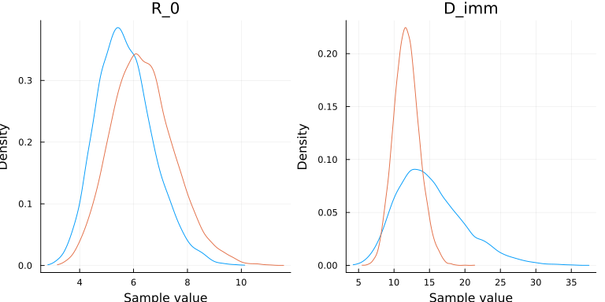

```julia
# Compare the fits visually
p1 = density(chain_seitl, :R_0, title="R_0", label="SEITL")
density!(p1, chain_pmcmc, :R_0, label="SEIT4L")

p2 = density(chain_seitl, :D_imm, title="D_imm", label="SEITL")
density!(p2, chain_pmcmc, :D_imm, label="SEIT4L")

plot(p1, p2, layout=(1, 2), size=(800, 400))
```

## Approaches to model comparison

Looking at the posterior densities above, we can see differences between the two models. But which model better explains the data? This is the question of *model comparison* or *model selection*.

There are three families of answer, and which of them applies is settled by how the model is built.

**Information criteria** estimate out-of-sample predictive accuracy, penalising complexity as they go, and they differ in what they ask of the model. The widely applicable information criterion (WAIC) and leave-one-out cross-validation (LOO) are the ones usually recommended. Both work from the pointwise predictive density and average over the whole posterior, and LOO carries diagnostics that say when its approximation has failed, with ParetoSmooth.jl providing an efficient approximation by Pareto-smoothed importance sampling (PSIS). Both also need the per-observation terms $p(y_i \mid \theta)$ to exist, and a stochastic latent trajectory takes those away. The Deviance Information Criterion (DIC) evaluates the deviance at the posterior mean, so it offers neither the posterior averaging nor the diagnostics, and it is the weaker choice wherever the pointwise criteria apply. However, it only requires the deviance of the whole series, which a particle filter estimates, so it can be used with PMCMC.

**Bayes factors** compare marginal likelihoods directly:

$$\text{BF}_{12} = \frac{P(\text{data}|M_1)}{P(\text{data}|M_2)}$$

Values > 10 indicate strong evidence for $M_1$; values < 0.1 indicate strong evidence for $M_2$. The marginal likelihood can be estimated from particle filter output using techniques like [path sampling](https://academic.oup.com/biomet/article/95/2/401/223193) or [thermodynamic integration](https://doi.org/10.1198/016214508000000571), but these are computationally intensive.

**Posterior predictive checks** ask which model generates data that looks like the observations. They give no single number, and what they offer instead is a view of *how* the models differ. They also apply whatever the model’s structure, which is the reason this session leans on them.

## Comparing parameter estimates

We can compare how the two models estimate the same parameters:

```julia
# Posterior means from each model
println("Posterior mean estimates:")
println("SEITL:")
println("  R_0 = $(round(mean(chain_seitl[:R_0]), digits=2))")
println("  D_imm = $(round(mean(chain_seitl[:D_imm]), digits=2))")

println("SEIT4L:")
println("  R_0 = $(round(mean(chain_pmcmc[:R_0]), digits=2))")
println("  D_imm = $(round(mean(chain_pmcmc[:D_imm]), digits=2))")
```

```
Posterior mean estimates:
SEITL:
  R_0 = 5.7
  D_imm = 15.18
SEIT4L:
  R_0 = 6.36
  D_imm = 11.77
```

The key difference is in the D_imm (duration of temporary immunity) estimates. SEIT4L, with its Erlang-distributed immunity duration, typically estimates a shorter mean duration but with less variance in timing.

## Comparing the two models

The criteria above are described but not computed, so nothing so far has actually compared the two models. We can do it directly with the chains we already have.

The pointwise criteria are the ones the model rules out, and it is worth seeing exactly where they fail. Both WAIC and LOO need the terms $p(y_i \mid \theta)$, and both assume the observations are independent once you condition on the parameters. The stochastic model puts a latent trajectory between the parameters and the data, so every day’s count depends on the same simulated path, and a particle filter estimates the likelihood of the whole series rather than handing you the per-observation contributions.

That assumption does hold in the deterministic sessions. There $\theta$ fixes the trajectory, each day’s count is an independent Poisson draw around it, and the likelihood factorises:

$$p(y \mid \theta) = \prod_{t} p(y_t \mid \theta)$$

which is what gives you the pointwise terms. Here the trajectory $X$ is itself random, and the observations depend on the parameters only through it:

$$p(y \mid \theta) = \int \prod_{t} p(y_t \mid X_t)\, p(X \mid \theta) \, \mathrm{d}X
\;\neq\; \prod_{t} p(y_t \mid \theta)$$

The integral is over the whole path at once, so it does not separate into a term per observation. Within any one run the series shares the single path that run took, and a second run takes a different one. That shared dependence is the feature that makes the model stochastic, and the particle filter estimates the left-hand side without ever forming the factors on the right.

DIC is the one that fits what a particle filter gives you. It needs the deviance $D(\theta) = -2 \log p(y \mid \theta)$ at the posterior mean, plus its spread across the posterior, and both come from the total likelihood alone. That is why [Camacho et al. (2011)](https://doi.org/10.1098/rspb.2011.0300) used it on these models, and it is the reason to reach for it here despite the general advice above.

First, the log-likelihood of every draw is already saved:

```julia
seitl_ll  = CSV.read(datadir("pmcmc_seitl_chain.csv"), DataFrame).loglikelihood
seit4l_ll = CSV.read(datadir("pmcmc_seit4l_chain.csv"), DataFrame).loglikelihood
println("mean log-likelihood, SEITL:  ", round(mean(seitl_ll), digits = 2))
println("mean log-likelihood, SEIT4L: ", round(mean(seit4l_ll), digits = 2))
```

```
mean log-likelihood, SEITL:  -121.66
mean log-likelihood, SEIT4L: -118.16
```

SEIT4L is ahead by about three and a half log-likelihood units, more than the spread of either chain, so this is not sampling noise. That agrees with [Camacho et al. (2011)](https://doi.org/10.1098/rspb.2011.0300), who preferred SEIT4L.

On its own that is not a comparison: a mean log-likelihood rewards fit and penalises nothing, so it will always favour the more flexible model. DIC adds the penalty, using the effective number of parameters $p_D$, taken as half the variance of the deviance across the posterior:

```julia
init_seit4l = [279.0, 0.0, 2.0, 3.0, 0.0, 0.0, 0.0, 0.0]

function dic(chain_df)
    p_D = var(-2 .* chain_df.loglikelihood) / 2
    θ_bar = Dict(:R_0 => mean(chain_df.R_0), :D_lat => mean(chain_df.D_lat),
                 :D_inf => mean(chain_df.D_inf), :α => mean(chain_df.α),
                 :D_imm => mean(chain_df.D_imm), :ρ => mean(chain_df.ρ))
    ## the filter estimate is noisy, so average a few runs at the posterior mean
    D_bar = -2 * mean(run_particle_filter(θ_bar, flu_tdc.obs, 256;
                                          init_state = init_seit4l) for _ in 1:5)
    return D_bar + 2 * p_D
end

Random.seed!(1)
println("DIC, SEITL:  ", round(dic(CSV.read(datadir("pmcmc_seitl_chain.csv"), DataFrame)), digits = 1))
println("DIC, SEIT4L: ", round(dic(CSV.read(datadir("pmcmc_seit4l_chain.csv"), DataFrame)), digits = 1))
```

```
DIC, SEITL:  263.3
DIC, SEIT4L: 246.5
```

Lower is better, and a gap of this size is large enough to take seriously. SEIT4L wins on both terms: it fits better *and* uses fewer effective parameters, which you would hope for from the model with the more realistic waiting time.

Two caveats specific to this setting. $p_D$ is computed from log-likelihoods the particle filter only estimates, so it carries a little of the filter’s noise as well as the posterior’s spread. With 256 particles that contribution is small here, and it grows as you cut the particle count.

The larger one is that DIC is not uniquely defined for a model with latent variables (Celeux et al. 2006). The deviance can be built on the observed data with the latent path integrated out, or on the complete data with the path treated as a parameter, and the two give different answers. The version above is the first, because the particle filter estimates $p(y \mid \theta)$ with the path already integrated out, and it is the version that keeps DIC’s usual justification. The conditional version treats the latent path as a parameter, and since the model carries one latent state per observation, its effective number of parameters grows with the data instead of measuring the model’s complexity. DIC’s justification assumes a fixed-dimensional parameter, so it lapses. Two better-suited options exist if you take this further. A one-step-ahead pseudo-DIC scores each observation against a prediction made from the state at the previous time point (Millar 2015), which is the natural predictive question for a time series. Alternatively, PMMH gives unbiased estimates of the marginal likelihood itself, so it can be estimated directly and compared across models. That comparison needs no separate complexity penalty: integrating over the prior already supplies one, because a model with more parameters spreads its prior mass over more datasets and so assigns less probability to any particular one. The cost of relying on it is a sensitivity to the priors themselves, which is the reason for the caution about Bayes factors above.

The marginal likelihood option needs the evidence integrated over the prior, and the filter gives $p(y \mid \theta)$ at a single parameter value, so that one is out of reach here. The one-step-ahead option is closer than it looks: the callback used for the filtered trajectories below also records the per-step log weights, whose increments are the one-step-ahead predictive densities the criterion asks for.

No single number can say whether the winner fits the data at all, so the comparison this session leans on is the posterior predictive one. Simulate from each posterior and look:

Each replicate draws parameters from the posterior and then runs the epidemic forward from the same starting state, so it gets a fresh latent trajectory. That costs wide envelopes, since every replicate re-rolls the whole outbreak along with the parameters. The alternative is to condition the trajectory on the observations, and we compare the two below.

```julia
init_seitl = Dict(:S => 279.0, :E => 0.0, :I => 2.0, :T => 3.0, :L => 0.0)
init_4l = [279.0, 0.0, 2.0, 3.0, 0.0, 0.0, 0.0, 0.0]
n_obs = length(flu_tdc.obs)

## one stochastic replicate per posterior draw, observed through the same
## Poisson reporting model the filter used
function predict_seitl(row)
    θ = Dict(:R_0 => row.R_0, :D_lat => row.D_lat, :D_inf => row.D_inf,
             :α => row.α, :D_imm => row.D_imm)
    traj = simulate_seitl_stochastic(θ, init_seitl, times_obs)
    [rand(Poisson(max(row.ρ * traj.Inc[i + 1], 1e-10))) for i in 1:n_obs]
end

function predict_seit4l(row)
    θ = Dict(:R_0 => row.R_0, :D_lat => row.D_lat, :D_inf => row.D_inf,
             :α => row.α, :D_imm => row.D_imm)
    state = copy(init_4l)
    [rand(Poisson(max(row.ρ * gillespie_step_seit4l!(state, θ, 1.0), 1e-10)))
     for _ in 1:n_obs]
end

Random.seed!(1)
n_sims = 200
seitl_df = CSV.read(datadir("pmcmc_seitl_chain.csv"), DataFrame)
seit4l_df = CSV.read(datadir("pmcmc_seit4l_chain.csv"), DataFrame)
sims_seitl = [predict_seitl(seitl_df[rand(1:nrow(seitl_df)), :]) for _ in 1:n_sims]
sims_seit4l = [predict_seit4l(seit4l_df[rand(1:nrow(seit4l_df)), :]) for _ in 1:n_sims]
```

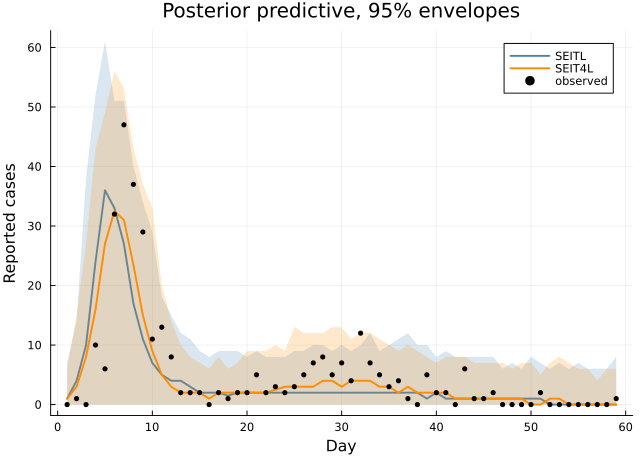

```julia
function envelope!(p, sims, label, colour)
    M = reduce(hcat, sims)
    lo = [quantile(M[t, :], 0.025) for t in 1:size(M, 1)]
    hi = [quantile(M[t, :], 0.975) for t in 1:size(M, 1)]
    med = [median(M[t, :]) for t in 1:size(M, 1)]
    plot!(p, flu_tdc.time, med, ribbon = (med .- lo, hi .- med),
          label = label, colour = colour, fillalpha = 0.2, linewidth = 2)
end

p = plot(xlabel = "Day", ylabel = "Reported cases",
         title = "Posterior predictive, 95% envelopes")
envelope!(p, sims_seitl, "SEITL", :steelblue)
envelope!(p, sims_seit4l, "SEIT4L", :darkorange)
scatter!(p, flu_tdc.time, flu_tdc.obs, label = "observed",
         colour = :black, markersize = 3)
```

Both envelopes contain almost every observation, so neither model is refuted by the data as a whole. The interesting question is the second wave, which the two models disagree about mechanically. Take its size as a test statistic and compute a Bayesian p-value, as in the model checking session:

```julia
second_wave = 25:45
observed_second = sum(flu_tdc.obs[second_wave])
for (name, sims) in (("SEITL", sims_seitl), ("SEIT4L", sims_seit4l))
    totals = [sum(v[second_wave]) for v in sims]
    println(rpad(name, 7), " second-wave cases: median ", median(totals),
            ", p = ", round(mean(totals .>= observed_second), digits = 3))
end
println("observed: ", observed_second)
```

```
SEITL   second-wave cases: median 60.0, p = 0.165
SEIT4L  second-wave cases: median 73.0, p = 0.235
observed: 88
```

**TipWhat to look for**

SEIT4L generates the larger second wave, which is the direction its mechanism predicts: Erlang-distributed immunity returns people to susceptible in a reasonably synchronised group, where SEITL’s exponential waiting time returns them steadily from the moment they recover and smears the wave out.

Notice what the p-values do not say, though. Both models undershoot the observed second wave, and neither is extreme enough to be rejected on this statistic. The better model here is the less-bad one. That is the limit of a comparison: it ranks the candidates you happened to write down, and says nothing about whether any of them is right.

## Where the latent trajectory comes from

The replicates above simulate the epidemic forward, so each one carries a latent path the filter never saw the data for. A particle filter can also hand back a path that *was* conditioned on the data. `DenseAncestorCallback` records the particles and their ancestor indices at every step, so drawing one particle at the end and following its ancestry back gives a whole trajectory:

```julia
Random.seed!(2)
n_filt = 200
sims_filtered = map(1:n_filt) do _
    row = seit4l_df[rand(1:nrow(seit4l_df)), :]
    θ = Dict(:R_0 => row.R_0, :D_lat => row.D_lat, :D_inf => row.D_inf,
             :α => row.α, :D_imm => row.D_imm, :ρ => row.ρ)
    inc = filtered_incidence(θ, flu_tdc.obs, 256)
    [rand(Poisson(max(row.ρ * x, 1e-10))) for x in inc]
end
```

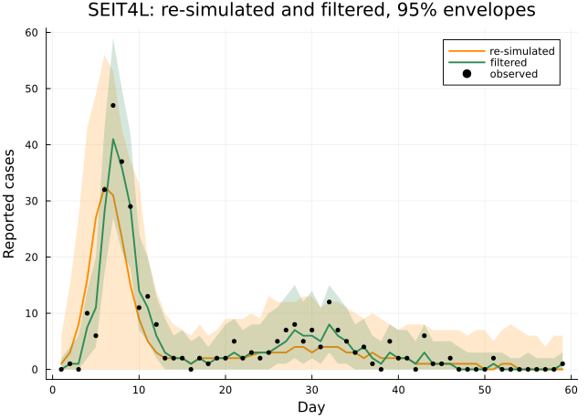

```julia
p = plot(xlabel = "Day", ylabel = "Reported cases",
         title = "SEIT4L: re-simulated and filtered, 95% envelopes")
envelope!(p, sims_seit4l, "re-simulated", :darkorange)
envelope!(p, sims_filtered, "filtered", :seagreen)
scatter!(p, flu_tdc.time, flu_tdc.obs, label = "observed",
         colour = :black, markersize = 3)
```

Both sets are draws of replicate data from the same fitted model, and they differ only in where the latent path comes from. The re-simulated replicates draw $\theta \sim p(\theta \mid y)$ and then a fresh path $X \sim p(X \mid \theta)$, with the latent path marginalised out of what the data informed. The filtered replicates draw the pair from the joint $p(\theta, X \mid y)$, so the path itself has been told the answer.

**Warning**

The filtered envelope is narrower on 51 of the 59 days, and less than half the width of the re-simulated one across the first wave. That tightness is not evidence of a better model. It tracks the observations because it was conditioned on them, and it would do so for a model that generates nothing like this outbreak when left to run. Judge fit with the re-simulated envelope. Read the filtered one as a picture of what the epidemic plausibly did, which is the question it answers well.

## Findings of the original study

[Camacho et al. (2011)](https://doi.org/10.1098/rspb.2011.0300) compared SEITL and SEIT4L using DIC and found that SEIT4L provided a better fit (lower DIC). This suggests that the *timing* of immunity loss matters - it’s not memoryless, as the exponential distribution in SEITL would imply.

The Erlang-4 distribution in SEIT4L has a coefficient of variation of 0.5 (compared to 1.0 for exponential), meaning individuals lose immunity at more consistent times. For the Tristan da Cunha data, this more realistic timing distribution better captures the second wave dynamics.

## Practical recommendations

For particle MCMC model comparison:

1. **Start with posterior predictive checks** - do the models make qualitatively different predictions? This check applies whatever the model, and it is what the section above does.
2. **Use WAIC or LOO where the observations are conditionally independent** - which covers the deterministic fits earlier in the course, but not a model with a stochastic latent trajectory. Check the assumption before reaching for the criterion.
3. **Fall back to DIC when the pointwise terms are out of reach** - it asks only for the deviance, which a particle filter can supply, and it is what the section above uses alongside the predictive check.
4. **Be cautious with Bayes factors** - they’re sensitive to prior choices and computationally expensive

When criteria disagree, consider what question you’re actually asking: best predictions (information criteria) or most probable model (Bayes factors)?

# Learning points

**TipLearning points**

- **Particle filters** estimate likelihoods for stochastic models by simulating many trajectories (particles) and weighting them by how well they match the data
- **Number of particles** should be calibrated so the standard deviation of the log-likelihood estimate is [between 1 and 3](https://doi.org/10.1016/j.jeconom.2012.06.004). The required number scales with problem complexity.
- **Stochastic vs deterministic**: stochastic models capture demographic stochasticity (important for small populations) but are much slower to fit
- **The model’s structure decides the criterion.** A stochastic latent trajectory leaves the observations dependent given the parameters, which rules out WAIC and LOO, and leaves DIC and the predictive check
- **Posterior predictive checks apply whatever the model is**, and the latent path has to come from the model for the check to have anything to fail at

# Going further

## Multiple chains and diagnostics

For production PMMH, you should run multiple chains and check convergence:

```julia
# Run multiple chains in parallel
chain_multi = sample(
    model_pmmh,
    externalsampler(AdvancedMH.RobustAdaptiveMetropolis()),
    MCMCThreads(),
    10000,
    4;
    num_warmup=10000,
    check_model=false
)

# Check R̂ and ESS statistics
summarystats(chain_multi)
```

Use the same diagnostics (R̂ < 1.1, ESS > 100) as for standard MCMC. Run it with four chains and compare their R̂ against the single chain fitted above. One chain can look perfectly healthy on its own trace and still have missed a region of the posterior, which is the failure only several chains started apart can show you.

## Alternative: Manual proposal tuning

If you need more control, you can use `MH()` with a covariance matrix instead of RAM. This is the same approach we used in the MCMC session:

```julia
# Manual covariance matrix (6 parameters, so 6x6 matrix)
# Diagonal entries are proposal variances, off-diagonal are covariances
Σ = [4.0  0.0  0.0  0.0  0.0  0.0;   # R_0
     0.0  0.04 0.0  0.0  0.0  0.0;   # D_lat
     0.0  0.0  0.25 0.0  0.0  0.0;   # D_inf
     0.0  0.0  0.0  0.01 0.0  0.0;   # α
     0.0  0.0  0.0  0.0  4.0  0.0;   # D_imm
     0.0  0.0  0.0  0.0  0.0  0.01]  # ρ

chain = sample(model_pmmh, MH(Σ), 5000)
```

This requires choosing proposal variances for each parameter - too large gives low acceptance, too small gives slow exploration. In practice, RAM is easier because it learns the covariance structure automatically.

Try it and compare the acceptance rate against the 23.6% RAM reached above. Matching that by hand takes several attempts, and the six variances above are only a starting point rather than a tuned answer.

## Particle Gibbs

**Particle Gibbs (PG)** is another PMCMC method, available in Turing via `PG(n_particles)`.

The methodological difference: PMMH uses the particle filter to estimate the marginal likelihood, then does standard Metropolis-Hastings on the parameters. PG conditions on a “reference trajectory” - one particle path from the previous iteration is retained, and the other particles are sampled conditional on it.

PG can exhibit high autocorrelation in some settings - [Lindsten et al. (2014)](https://jmlr.org/papers/v15/lindsten14a.html) discuss this and propose the Particle Gibbs with Ancestor Sampling (PGAS) algorithm as an improvement.

## Filtered trajectories

PMCMC methods can provide **filtered trajectories** - stochastic trajectories from the model conditioned on both the estimated parameters and the observed data. These are useful for visualising what the underlying epidemic dynamics might have looked like, given what we observed.

The model comparison above plots these against the re-simulated replicates, using `filtered_incidence` from the course package. It samples one particle at the final time point, weighted by the particle weights, and reconstructs its path back through time, which gives one draw from the posterior over trajectories. Repeating across MCMC iterations gives a collection of plausible epidemic histories.

One caveat that plot does not show: within a single filter run the surviving particles share ever fewer distinct ancestors as you trace them back, so the early part of any one path is drawn from a handful of histories rather than from the full smoothing distribution. Drawing many paths from one run would therefore understate the uncertainty badly. The plot above avoids that by re-running the filter for every replicate, at a fresh posterior draw, so the paths are independent of each other.

See [Doucet & Johansen (2009)](https://www.stats.ox.ac.uk/~doucet/doucet_johansen_tutorialPF2011.pdf) for details on trajectory sampling from particle filters.

## Calibrating the particle count and the proposal together

This session calibrated the particle count in one place and let RAM adapt the proposal in another, as though the two were separate problems. They are not. A rejection costs a particle filter run once the likelihood is estimated, so the count and the proposal are one calibration. [Sherlock, Thiery, Roberts & Rosenthal (2015)](https://doi.org/10.1214/14-AOS1278) work out the efficient combination for pseudo-marginal random walk Metropolis: a log-likelihood standard deviation near 1.8, with an acceptance rate near 7%. Both figures are limits for a large number of parameters and assume a particular form for the noise, as the 23.4% in the MCMC session does, so they are a guide rather than a setting to copy.

Hitting either target still takes a pilot run. [Abaoubida, Bédard & Maire (2025)](https://arxiv.org/abs/2509.24820) instead adapt the particle count as the chain runs, and prove that the sampler stays ergodic as long as the adaptation fades out.

## SMC²

SMC² (SMC squared) uses Sequential Monte Carlo for both parameters and state trajectories, avoiding MCMC entirely. This can be more efficient for complex models but requires more careful tuning. Turing.jl supports this through the `SMC` sampler. Adapting the number of state particles is further along here than it is for PMMH: [Botha, Kohn, South & Drovandi (2023)](https://doi.org/10.1007/s11222-023-10250-2) change it automatically as the algorithm runs, using the expected squared jumping distance of the rejuvenation moves to decide when. See [Chopin, Jacob & Papaspiliopoulos (2013)](https://doi.org/10.1111/j.1467-9868.2012.01046.x), which introduced the algorithm, for how the two layers of particles fit together.

## Amortised inference

Every chain in this session answered a question about a single dataset. Fit the same model to a second island, or to a different reporting schedule, and the whole cost is paid again.

Neural posterior estimation is an advanced session that trains a neural network on simulations from this same SEITL model, so that afterwards a posterior costs milliseconds for any dataset the model can produce. It is approximate where PMMH is exact, and it pays off when you fit the same model repeatedly.

# Next session

In Observation Models and Distance Metrics, we’ll step back and examine a fundamental question: why do we choose Poisson likelihoods, and what are the alternatives?

# References

- Andrieu et al. (2010). [Particle Markov chain Monte Carlo methods](https://doi.org/10.1111/j.1467-9868.2009.00736.x). *JRSS B* 72(3), 269-342. (The original PMCMC paper)
- Pitt et al. (2012). [On some properties of Markov chain Monte Carlo simulation methods based on the particle filter](https://doi.org/10.1016/j.jeconom.2012.06.004). *Journal of Econometrics* 171(2), 134-151. (Particle calibration: target log-likelihood SD of 1-3)
- Vihola (2012). [Robust adaptive Metropolis algorithm with coerced acceptance rate](https://doi.org/10.1007/s11222-011-9269-5). *Statistics and Computing* 22, 997-1008. (RAM algorithm used in this session)
- Roberts & Rosenthal (2009). [Examples of Adaptive MCMC](https://doi.org/10.1198/jcgs.2009.06134). *J. Computational and Graphical Statistics* 18(2), 349-367. (Adaptive MCMC theory)
- Doucet & Johansen (2009). [A tutorial on particle filtering and smoothing](https://www.stats.ox.ac.uk/~doucet/doucet_johansen_tutorialPF2011.pdf). *Handbook of Nonlinear Filtering* 12, 656-704. (Trajectory sampling)
- Doucet et al. (2015). [Efficient implementation of Markov chain Monte Carlo when using an unbiased likelihood estimator](https://doi.org/10.1093/biomet/asu075). *Biometrika* 102(2), 295-313.
- Doucet et al. (2001). [Sequential Monte Carlo Methods in Practice](https://www.springer.com/gp/book/9780387951461). Springer. (Comprehensive textbook)
- Arulampalam et al. (2002). [A tutorial on particle filters for online nonlinear/non-Gaussian Bayesian tracking](https://doi.org/10.1109/78.978374). *IEEE Trans. Signal Processing* 50(2), 174-188.
- [Turing.jl documentation](https://turinglang.org/stable/) - Probabilistic programming in Julia

## References

Celeux, Gilles, Florence Forbes, Christian P. Robert, and D. Mike Titterington. 2006. “Deviance Information Criteria for Missing Data Models.” *Bayesian Analysis* 1 (4): 651–73. https://doi.org/10.1214/06-BA122.

Millar, Russell B. 2015. “A One-Step-Ahead Pseudo-DIC for Comparison of Bayesian State-Space Models.” *Biometrics* 71 (1): 201–6. https://doi.org/10.1111/biom.12237.